# Practicum Enrichment Analysis

# 5 Gene Set Enrichment Analysis (GSEA)

## 5.1 Preparation of a ranked gene list

We can rank genes by their logFC so that most up/down-regulated genes will be at the top/bottom of the list, respectively.

```r
genelist <- toptab$logFC
names(genelist) <- as.character(toptab$entrez)
sum(is.na(genelist))
```

```
## [1] 0
```

```r
length(genelist)
```

```
## [1] 15521
```

```r
#sort in decreasing order
genelist <- sort(genelist, decreasing=TRUE)
head(genelist)
```

```
##   140474    16071    71874   110935    12740    21819
## 6.750028 6.135350 5.508106 5.321891 5.314006 5.161936
```

```r
tail(genelist)
```

```
##    328505     14618    211577     76964     21953     12992
## -4.606118 -4.663490 -5.146268 -5.252768 -5.827889 -6.070143
```

## 5.2 GSEA over GO-BP ontology

To run the GSEA analysis we will use `gseGO` function from `clusterProfiler` package.

```r
gsea_go <- gseGO(geneList=genelist,
                 keyType = "ENTREZID",
                 OrgDb = org.Mm.eg.db,
                 ont = "BP",
                 pAdjustMethod = "BH",
                 pvalueCutoff = 0.05,
                 by = "fgsea")
head(gsea_go)
```

```
##                    ID                          Description setSize
## GO:0000070 GO:0000070 mitotic sister chromatid segregation     146
## GO:0000280 GO:0000280                     nuclear division     364
## GO:0000819 GO:0000819         sister chromatid segregation     172
## GO:0006364 GO:0006364                      rRNA processing     205
## GO:0007059 GO:0007059               chromosome segregation     291
## GO:0016072 GO:0016072               rRNA metabolic process     212
##            enrichmentScore      NES pvalue p.adjust      qvalues rank
## GO:0000070       0.6690906 2.520274  1e-10 5.28e-08 4.496651e-08 1816
## GO:0000280       0.4992873 2.017073  1e-10 5.28e-08 4.496651e-08 1816
## GO:0000819       0.6441655 2.440438  1e-10 5.28e-08 4.496651e-08 1816
## GO:0006364       0.5740169 2.217629  1e-10 5.28e-08 4.496651e-08 3938
## GO:0007059       0.5620687 2.242337  1e-10 5.28e-08 4.496651e-08 1958
## GO:0016072       0.5606415 2.171589  1e-10 5.28e-08 4.496651e-08 3938
##                              leading_edge
## GO:0000070 tags=36%, list=12%, signal=32%
## GO:0000280 tags=26%, list=12%, signal=23%
## GO:0000819 tags=34%, list=12%, signal=30%
## GO:0006364 tags=57%, list=25%, signal=43%
## GO:0007059 tags=30%, list=13%, signal=27%
## GO:0016072 tags=55%, list=25%, signal=42%
##                                                                                                                                                                                                                                                                                                          …
## GO:0000070                                                                                                                                                                                                                                                                                               …
## GO:0000280                                                                                                                                                  16878/20877/12235/71819/66977/54392/14087/100502766/12704/26…
## GO:0000819                                                                                                                                                                                                                                                                                               …
## GO:0006364        24014/271842/72515/102614/59028/107094/14113/52530/67223/724…
## GO:0007059                                                                                                                                                                                            20877/12235/66468/71819/66977/54392/12704/26934/108000/52276…
## GO:0016072 24014/271842/72515/102614/59028/107094/14113/52530/67223/724…
```

```r
gsea_go_results <- data.frame(gsea_go)
write.csv(gsea_go_results, "clusterProfiler_GSEAresults_GO.csv")
```

### 5.2.1 Visualization of results

**Dotplot**

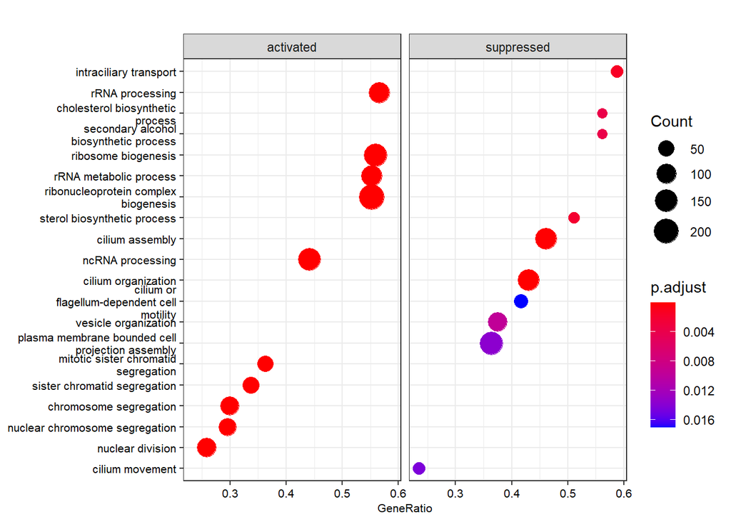

```r
library(DOSE)
dotplot(gsea_go, showCategory=10, font.size=8, split=".sign") + facet_grid(.~.sign)
```

**GSEA plot**

The following plot shows the Running Enrichment Score obtained for the first gene set, as an example:

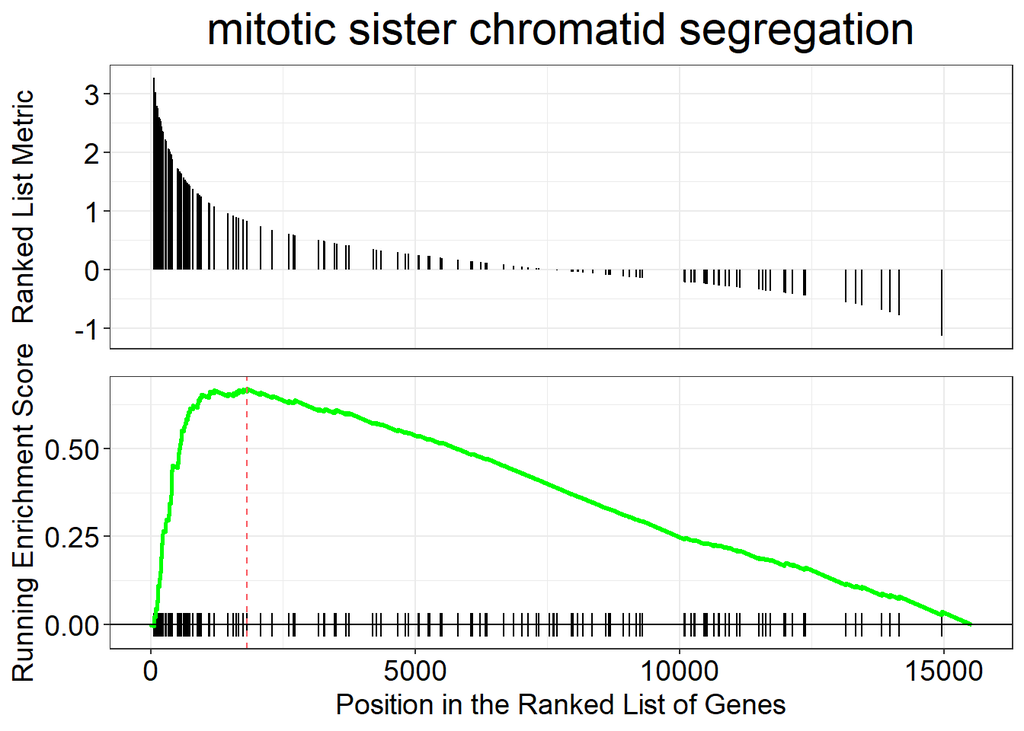

```r
gseaplot(gsea_go, title=gsea_go$Description[1], geneSetID=1)
```

**Challenge**: perform an Enrichment Map with the results of GSEA analysis.